# ggplot Line Plot Multiple Categorical Variables With Continuous Variable

[Fan Wang](https://fanwangecon.github.io/)

2021-09-12

# 1 ggplot Line Advanced

> Go to the [**RMD**](https://github.com/FanWangEcon//R4Econ/blob/master/tabgraph/ggline//fs_ggline_mgrp_ncts.Rmd), [**R**](https://github.com/FanWangEcon//R4Econ/blob/master/tabgraph/ggline//htmlpdfr/fs_ggline_mgrp_ncts.R), [**PDF**](https://github.com/FanWangEcon//R4Econ/blob/master/tabgraph/ggline//htmlpdfr/fs_ggline_mgrp_ncts.pdf), or [**HTML**](https://fanwangecon.github.io//R4Econ/tabgraph/ggline//htmlpdfr/fs_ggline_mgrp_ncts.html) version of this file. Go back to [fan](http://fanwangecon.github.io/)’s [REconTools](https://fanwangecon.github.io/REconTools/) research support package, [R4Econ](https://fanwangecon.github.io/R4Econ/) examples page, [PkgTestR](https://fanwangecon.github.io/PkgTestR/) packaging guide, or [Stat4Econ](https://fanwangecon.github.io/Stat4Econ/) course page.

## 1.1 Continuous Y and X Variables, Three Categories, One is Subplot

Visualize one continuous variable, along the x-axis, given three categorical variables, with 12 combined categories $3\times2\times2=12$:

- one as subplot (productivity type), 3 unique values
- one as line-color (gamma levels), 2 unique values
- one as line-type (GE vs PE), 2 unique values

The outcome is continuous CEV, generated for results with different productivity types (subplot), generated for PE vs GE (linetype), and at different parameter specifications (lower and higher gamma). X-axis is continuous. The graphs rely on this csv file [cev_data.csv](https://github.com/FanWangEcon/R4Econ/tree/master/tabgraph/ggline/_file).

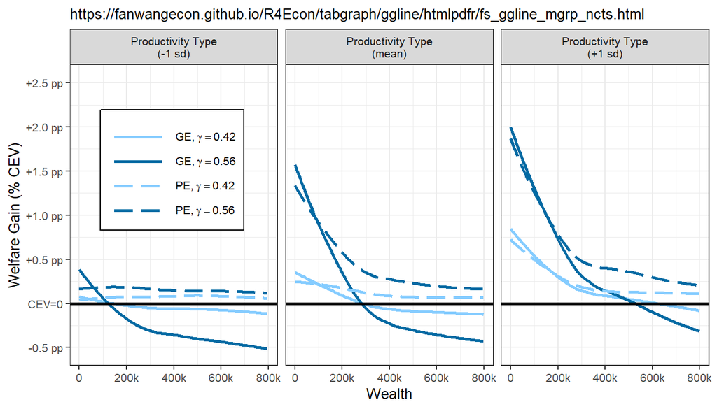

```r
# Libraries
# library(tidyverse)

# Load in CSV
bl_save_img <- TRUE
spt_csv_root <- c("C:/Users/fan/R4Econ/tabgraph/ggline/_file/")
spt_img_root <- c("C:/Users/fan/R4Econ/tabgraph/ggline/_file/")
spn_cev_data <- paste0(spt_csv_root, "cev_data.csv")
spn_cev_graph <- paste0(spt_img_root, "cev_graph.png")
spn_cev_graph_eps <- paste0(spt_img_root, "cev_graph.eps")
df_cev_graph <- as_tibble(read.csv(spn_cev_data)) %>% select(-X)

# Dataset subsetting ------

# Line Patterns and Colors ------
# ar_st_age_group_leg_labels <- c("\nGE\n\u03B3=0.42\n", "\nGE\n\u03B3=0.56\n",
#                                 "\nPE\n\u03B3=0.42\n", "\nPE\n\u03B3=0.42\n")
ar_st_age_group_leg_labels <- c(
  bquote("GE," ~ gamma == .(0.42)),
  bquote("GE," ~ gamma == .(0.56)),
  bquote("PE," ~ gamma == .(0.42)),
  bquote("PE," ~ gamma == .(0.56))
)
ar_st_colours <- c("#85ccff", "#026aa3", "#85ccff", "#026aa3")
ar_st_linetypes <- c("solid", "solid", "longdash", "longdash")

# Labels and Other Strings -------
st_title <- ""
st_x <- "Wealth"
st_y <- "Welfare Gain (% CEV)"
st_subtitle <- paste0(
  "https://fanwangecon.github.io/",
  "R4Econ/tabgraph/ggline/htmlpdfr/fs_ggline_mgrp_ncts.html"
)

# ar_st_age_group_leg_labels <- c("C\u2013Optimal", "V\u2013Optimal")

prod_type_recode <- c(
  "Productivity Type\n(-1 sd)" = "8993",
  "Productivity Type\n(mean)" = "10189",
  "Productivity Type\n(+1 sd)" = "12244"
)

x_labels <- c("0", "200k", "400k", "600k", "800k")
x_breaks <- c(
  0,
  5,
  10,
  15,
  20
)
x_min <- 0
x_max <- 20

# y_labels <- c('-0.01',
#               '\u2191\u2191\nWelfare\nGain\n\nCEV=0\n\nWelfare\nLoss\n\u2193\u2193',
#               '+0.01', '+0.02', '+0.03', '+0.04','+0.05')
y_labels <- c(
  "-0.5 pp",
  "CEV=0",
  "+0.5 pp", "+1.0 pp", "+1.5 pp", "+2.0 pp", "+2.5 pp"
)
y_breaks <- c(-0.01, 0, 0.01, 0.02, 0.03, 0.04, 0.05)
y_min <- -0.011
y_max <- 0.051

# data change -------
df_cev_graph <- df_cev_graph %>%
  filter(across(counter_policy, ~ grepl("70|42", .))) %>%
  mutate(prod_type_lvl = as.factor(prod_type_lvl)) %>%
  mutate(prod_type_lvl = fct_recode(prod_type_lvl, !!!prod_type_recode))

# graph ------
pl_cev <- df_cev_graph %>%
  group_by(prod_type_st, cash_tt) %>%
  ggplot(aes(
    x = cash_tt, y = cev_lvl,
    colour = counter_policy, linetype = counter_policy, shape = counter_policy
  )) +
  facet_wrap(~prod_type_lvl, nrow = 1) +
  geom_smooth(method = "auto", se = FALSE, fullrange = FALSE, level = 0.95)

# labels
pl_cev <- pl_cev +
  labs(
    x = st_x,
    y = st_y,
    subtitle = st_subtitle
  )

# set shapes and colors
pl_cev <- pl_cev +
  scale_colour_manual(values = ar_st_colours, labels = ar_st_age_group_leg_labels) +
  scale_shape_discrete(labels = ar_st_age_group_leg_labels) +
  scale_linetype_manual(values = ar_st_linetypes, labels = ar_st_age_group_leg_labels) +
  scale_x_continuous(
    labels = x_labels, breaks = x_breaks,
    limits = c(x_min, x_max)
  ) +
  scale_y_continuous(
    labels = y_labels, breaks = y_breaks,
    limits = c(y_min, y_max)
  )

# Horizontal line
pl_cev <- pl_cev +
  geom_hline(yintercept = 0, linetype = "solid", colour = "black", size = 1)
# geom_hline(yintercept=0, linetype='dotted', colour="black", size=2)

# theme
pl_cev <- pl_cev +
  theme_bw() +
  theme(
    text = element_text(size = 10),
    legend.title = element_blank(),
    legend.position = c(0.16, 0.65),
    legend.background = element_rect(
      fill = "white",
      colour = "black",
      linetype = "solid"
    ),
    legend.key.width = unit(1.5, "cm")
  )

# Print Images to Screen -----
print(pl_cev)
```

```r
# Save Image Outputs -----
if (bl_save_img) {
  png(spn_cev_graph,
    width = 160,
    height = 105, units = "mm",
    res = 150, pointsize = 7
  )
  ggsave(
    spn_cev_graph_eps,
    plot = last_plot(),
    device = "eps",
    path = NULL,
    scale = 1,
    width = 200,
    height = 100,
    units = c("mm"),
    dpi = 150,
    limitsize = TRUE
  )
  print(pl_cev)
  dev.off()
}
```

## 1.2 Continuous Y and X Variables, Two Categories, One is Subplot

- one as subplot (GE vs PE), 2 unique values
- one with line-color, line-color and scatter shape joint variation (counterfactual type), 5 unique values

The outcome is change in male and female labor participation gaps, generated under partial and general equilibrium (subplot), generated for different counterfactual policies (linetype). X-axis is calendar year. Features:

For data processing, converts all possible numerical variables to numeric.

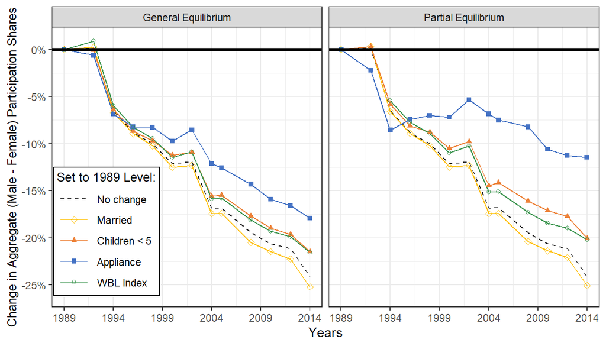

```r
# Load in CSV
bl_save_img <- TRUE
spt_csv_root <- c("C:/Users/fan/R4Econ/tabgraph/ggline/_file/")
spt_img_root <- spt_csv_root
spn_flfp_sklocc_data <- paste0(spt_csv_root, "flfp_data.csv")
spn_flfp_sklocc_graph <- paste0(spt_img_root, "flfp_sam2fshr_graph.png")
spn_flfp_sklocc_graph_eps <- paste0(spt_img_root, "flfp_sam2fshr_graph.eps")

# Load data
# Convert all convertable numeric columns from string to numeric
# https://stackoverflow.com/a/49054046/8280804
is_all_numeric <- function(x) {
  !any(is.na(suppressWarnings(as.numeric(na.omit(x))))) & is.character(x)
}
df_flfp <- as_tibble(read.csv(spn_flfp_sklocc_data)) %>%
  mutate_if(is_all_numeric, as.numeric) %>%
  filter(year <= 2014)

# Dataset subsetting ------

# Line Patterns and Colors ------
ctr_var_recode <- c(
  "No change" = "1",
  "Married" = "31",
  "Children < 5" = "32",
  "Appliance" = "33",
  "WBL Index" = "34"
)

# https://www.rgbtohex.net/
ar_st_colours <- c("#262626", "#FFC001", "#ED8137", "#4472C4", "#3E9651")
# http://www.sthda.com/english/wiki/ggplot2-line-types-how-to-change-line-types-of-a-graph-in-r-software
ar_st_linetypes <- c("dashed", "solid", "solid", "solid", "solid")
# http://sape.inf.usi.ch/quick-reference/ggplot2/shape
# 32 is invisible shape
ar_it_shapes <- c(32, 5, 17, 15, 1)

# Labels and Other Strings -------
st_title <- ""
st_x <- "Years"
st_y <- "Change in Aggregate (Male - Female) Participation Shares"
st_subtitle <- paste0(
  "https://fanwangecon.github.io/",
  "R4Econ/tabgraph/ggline/htmlpdfr/fs_ggline_mgrp_ncts.html"
)

# ge_pe_recode <- c(
#   "General Equilibrium\n(Adjust Wages)" = "GE",
#   "Partial Equilibrium\n(Wage as Observed)" = "PE"
# )
ge_pe_recode <- c(
  "General Equilibrium" = "GE",
  "Partial Equilibrium" = "PE"
)
# x.breaks <- c(1989, seq(1992, 2004, by = 2), 2005, seq(2008, 2014, by = 2))
# x.labels <- paste(x.breaks[1:13])
x.breaks <- seq(1989, 2014, by = 5)
x.labels <- paste(x.breaks[1:6])
x.min <- 1989
x.max <- 2014

y.breaks <- round(seq(-0.30, 0.05, by = 0.05), 2)
y.labels <- paste0(paste(y.breaks[1:length(y.breaks)] * 100), "%")

y.min <- -0.26
y.max <- 0.01

# data change -------
df_flfp_sklocc_graph <- df_flfp %>%
  filter(ctr_var_idx %in% c(1, 31, 32, 33, 34) & category == "C001") %>%
  mutate(
    ge_pe = as.factor(ge_pe),
    ctr_var_idx = as.factor(ctr_var_idx)
  ) %>%
  mutate(ge_pe = fct_recode(ge_pe, !!!ge_pe_recode)) %>%
  mutate(ctr_var_idx = fct_recode(ctr_var_idx, !!!ctr_var_recode)) %>%
  select(year, ctr_var_idx, ge_pe, part_yeargender_shr_m2f_dfv1st)

# graph ------
pl_flfp_agg <- df_flfp_sklocc_graph %>%
  ggplot(aes(
    x = year, y = part_yeargender_shr_m2f_dfv1st,
    colour = ctr_var_idx, linetype = ctr_var_idx, shape = ctr_var_idx
  )) +
  facet_wrap(~ge_pe, nrow = 1) +
  geom_line() +
  geom_point()

# labels
pl_flfp_agg <- pl_flfp_agg +
  labs(
    x = st_x,
    y = st_y
  )
# subtitle = st_subtitle

# set shapes and colors
# scale_colour_manual(values = ar_st_colours, labels = ctr_var_recode) +
# scale_shape_manual(values=ar_it_shapes, labels = ctr_var_recode) +
# scale_linetype_manual(values = ar_st_linetypes, labels = ctr_var_recode) +
pl_flfp_agg <- pl_flfp_agg +
  scale_colour_manual(values = ar_st_colours) +
  scale_shape_manual(values = ar_it_shapes) +
  scale_linetype_manual(values = ar_st_linetypes) +
  scale_x_continuous(
    labels = x.labels, breaks = x.breaks,
    limits = c(x.min, x.max)
  ) +
  scale_y_continuous(
    labels = y.labels, breaks = y.breaks,
    limits = c(y.min, y.max)
  )

# Horizontal line
pl_flfp_agg <- pl_flfp_agg +
  geom_hline(yintercept = 0, linetype = "solid", colour = "black", size = 1)
# geom_hline(yintercept=0, linetype='dotted', colour="black", size=2)

# theme
pl_flfp_agg <- pl_flfp_agg +
  theme_bw() +
  theme(
    text = element_text(size = 11),
    legend.title = element_text(size = 10),
    legend.margin = margin(c(0.1, 0.1, 0.1, 0.1), unit = "cm"),
    legend.position = c(0.10, 0.27),
    legend.background = element_rect(
      fill = "white",
      colour = "black",
      linetype = "solid"
    ),
    legend.key.width = unit(1.0, "cm"),
    axis.title.y = element_text(size = 10)
  ) +
  guides(
    color = guide_legend(title = "Set to 1989 Level:"),
    linetype = guide_legend(title = "Set to 1989 Level:"),
    shape = guide_legend(title = "Set to 1989 Level:")
  )

# Print Images to Screen
print(pl_flfp_agg)
```

```r
# Save Image Outputs -----
if (bl_save_img) {
  png(spn_flfp_sklocc_graph,
    width = 200,
    height = 100, units = "mm",
    res = 150, pointsize = 7
  )
  ggsave(
    spn_flfp_sklocc_graph_eps,
    plot = last_plot(),
    device = "eps",
    path = NULL,
    scale = 1,
    width = 200,
    height = 100,
    units = c("mm"),
    dpi = 150,
    limitsize = TRUE
  )
  print(pl_flfp_agg)
  dev.off()
}
```

## 1.3 Continuous Y and X Variables, Four Categories, Three for Subplot

- one as plot, generate three different plots, 3 unique values, achieved by saving a function and running the function three times with variable conditioning.
- one as *facet_grid* row group, 2 unique values.
- one as *facet_grid* column group, 2 unique values.
- one with line-color, line-color and scatter shape joint variation (counterfactual type), 3 unique values

Following the example above, continue to analyze female labor participation. Generated under partial and general equilibrium (subplot), and skill and occupational groups. , generated for different counterfactual policies (linetype). X-axis is calendar year.

First define the graphing function:

```r
# The graphing function with limited parameter options.
ff_grhlfp_gepeedu_byocc <-
  function(bl_save_img = TRUE,
           st_occ = "Manual",
           y_breaks = round(seq(0.08, 0.18, by = 0.02), 2),
           y_min = 0.08,
           y_max = 0.19,
           ar_leg_position = c(0.29, 0.50),
           it_width = 160, it_height = 105,
           st_subtitle = paste0(
             "https://fanwangecon.github.io/",
             "R4Econ/tabgraph/ggline/htmlpdfr/fs_ggline_mgrp_ncts.html"
           )) {

    # Load in CSV
    spt_csv_root <- c("C:/Users/fan/R4Econ/tabgraph/ggline/_file/")
    spt_img_root <- spt_csv_root
    spn_flfp_sklocc_data <- paste0(spt_csv_root, "flfp_data.csv")
    spn_flfp_sklocc_graph <- paste0(
      spt_img_root,
      paste0("flfp_gepe_colhigh_", tolower(st_occ), "_graph.png")
    )
    spn_flfp_sklocc_graph_eps <- paste0(
      spt_img_root,
      paste0("flfp_gepe_colhigh_", tolower(st_occ), "_graph.eps")
    )

    # Load data
    # Convert all convertable numeric columns from string to numeric
    # https://stackoverflow.com/a/49054046/8280804
    is_all_numeric <- function(x) {
      !any(is.na(suppressWarnings(as.numeric(na.omit(x))))) & is.character(x)
    }
    df_flfp <- as_tibble(read.csv(spn_flfp_sklocc_data)) %>%
      mutate_if(is_all_numeric, as.numeric) %>%
      filter(year <= 2014)

    # Dataset subsetting ------

    # Line Patterns and Colors ------
    ctr_var_recode <- c(
      "Prediction no Counterfactual" = "1",
      "Married at 1989 Levels" = "31",
      "Children < 5 at 1989 Levels" = "32",
      "Appliance at 1989 Levels" = "33",
      "WBL Index at 1989 Levels" = "34"
    )

    # https://www.rgbtohex.net/
    # ar_st_colours <- c("#262626", "#FFC001", "#ED8137", "#4472C4", "#3E9651")
    ar_st_colours <- c("#262626", "#ED8137", "#4472C4")
    # http://www.sthda.com/english/wiki/ggplot2-line-types-how-to-change-line-types-of-a-graph-in-r-software
    ar_st_linetypes <- c("dashed", "solid", "solid")
    # http://sape.inf.usi.ch/quick-reference/ggplot2/shape
    # 32 is invisible shape
    # ar_it_shapes <- c(32, 5, 17, 15, 1)
    ar_it_shapes <- c(32, 17, 15)

    # Labels and Other Strings -------
    st_x <- "Years"
    st_y <- paste0("Female ", st_occ, " Occupation Participation Shares")

    # ge_pe_recode <- c(
    #   "General Equilibrium\n(Adjust Wages)" = "GE",
    #   "Partial Equilibrium\n(Wage as Observed)" = "PE"
    # )
    ge_pe_recode <- c(
      "General Equilibrium" = "GE",
      "Partial Equilibrium" = "PE"
    )
    # ge_pe_recode <- c(
    #   "GE" = "GE",
    #   "PE" = "PE"
    # )

    skilled_unskilled_recode <- c(
      "College Women" = "skilled",
      "Secondary Women" = "unskilled"
    )

    # x_breaks <- seq(1989, 2014, by = 5)
    x_breaks <- c(1990, 1995, 2000, 2005, 2010)
    x_labels <- paste(x_breaks[1:length(x_breaks)])
    x_min <- 1989
    x_max <- 2014

    # y_breaks <- round(seq(0.08, 0.18, by = 0.02), 2)
    y_labels <- paste0(paste(y_breaks[1:length(y_breaks)] * 100), "%")

    # y_min <- 0.08
    # y_max <- 0.19

    # data change -------
    df_flfp_sklocc_graph <- df_flfp %>%
      filter(ctr_var_idx %in% c(1, 32, 33) &
        gender == "Female" &
        occupation %in% c(st_occ)) %>%
      mutate(
        ge_pe = as.factor(ge_pe),
        ctr_var_idx = as.factor(ctr_var_idx)
      ) %>%
      mutate(
        ge_pe = fct_recode(ge_pe, !!!ge_pe_recode),
        skill = fct_recode(skill, !!!skilled_unskilled_recode),
        ctr_var_idx = fct_recode(ctr_var_idx, !!!ctr_var_recode)
      ) %>%
      select(year, skill, occupation, ctr_var_idx, ge_pe, genskl_part_share)

    # graph ------
    pl_flfp_sklocc <- df_flfp_sklocc_graph %>%
      ggplot(aes(
        x = year, y = genskl_part_share,
        colour = ctr_var_idx, linetype = ctr_var_idx, shape = ctr_var_idx
      )) +
      facet_grid(skill ~ ge_pe) +
      geom_line() +
      geom_point()

    # labels
    if (st_subtitle == "") {
      pl_flfp_sklocc <- pl_flfp_sklocc +
        labs(
          x = st_x,
          y = st_y
        )
    } else {
      pl_flfp_sklocc <- pl_flfp_sklocc +
        labs(
          x = st_x,
          y = st_y,
          subtitle = st_subtitle
        )
    }

    # set shapes and colors
    pl_flfp_sklocc <- pl_flfp_sklocc +
      scale_colour_manual(values = ar_st_colours) +
      scale_shape_manual(values = ar_it_shapes) +
      scale_linetype_manual(values = ar_st_linetypes) +
      scale_x_continuous(
        labels = x_labels, breaks = x_breaks,
        limits = c(x_min, x_max)
      ) +
      scale_y_continuous(
        labels = y_labels, breaks = y_breaks,
        limits = c(y_min, y_max)
      )

    # theme
    pl_flfp_sklocc <- pl_flfp_sklocc +
      theme_bw() +
      theme(
        text = element_text(size = 11),
        panel.grid.minor = element_blank(),
        legend.title = element_blank(),
        legend.position = ar_leg_position,
        legend.margin = margin(c(0.1, 0.1, 0.1, 0.1), unit = "cm"),
        legend.background = element_rect(
          fill = "white",
          colour = "black",
          linetype = "solid"
        ),
        legend.key.width = unit(1.0, "cm"),
        axis.text.x = element_text(angle = 45, vjust = 0.1, hjust = 0.1)
        # axis.text.y = element_text(angle = 90, hjust = 0.4)
      )
    # element_text(angle = 90, hjust = 0.4)
    # axis.title.y = element_blank(), # no y-label

    # Save Image Outputs -----
    if (bl_save_img) {
      ggsave(
        spn_flfp_sklocc_graph,
        plot = last_plot(),
        device = "png",
        path = NULL,
        scale = 1,
        width = it_width,
        height = it_height,
        units = c("mm"),
        dpi = 150,
        limitsize = TRUE
      )
      ggsave(
        spn_flfp_sklocc_graph_eps,
        plot = last_plot(),
        device = "eps",
        path = NULL,
        scale = 1,
        width = it_width,
        height = it_height,
        units = c("mm"),
        dpi = 150,
        limitsize = TRUE
      )
       # dev.off()
    }

    return(pl_flfp_sklocc)
  }
```

Second, run the function, for Manual, Routine and Analytical Works Separately.

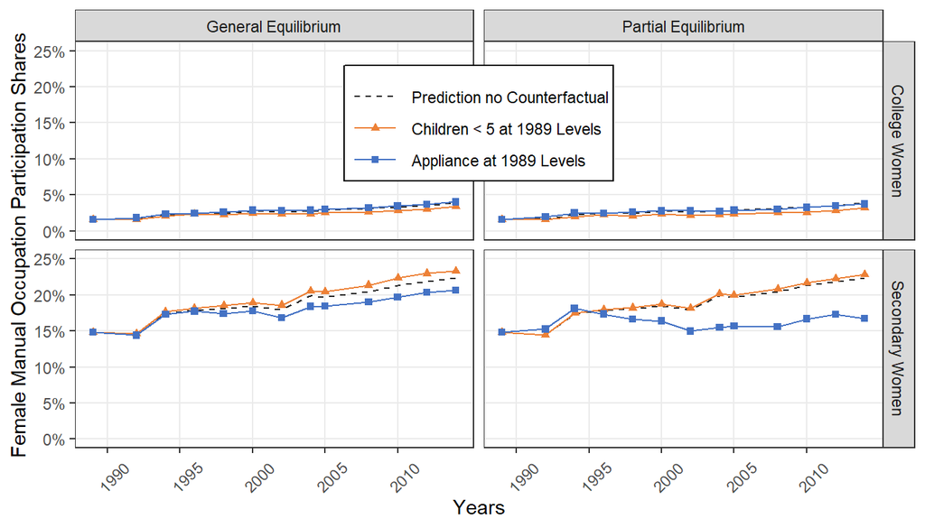

```r
it_width <- 100
it_height <- 100
st_subtitle <- paste0(
  "https://fanwangecon.github.io/",
  "R4Econ/tabgraph/ggline/htmlpdfr/fs_ggline_mgrp_ncts.html"
)
st_subtitle <- ""
# Manual,
pl_flfp_sklocc_manual <- ff_grhlfp_gepeedu_byocc(
  bl_save_img = TRUE,
  st_occ = "Manual",
  y_breaks = round(seq(0.00, 0.25, by = 0.05), 2),
  y_min = 0.00, y_max = 0.25,
  ar_leg_position = c(0.50, 0.80),
  it_width = it_width, it_height = it_height,
  st_subtitle = st_subtitle
)
print(pl_flfp_sklocc_manual)
```

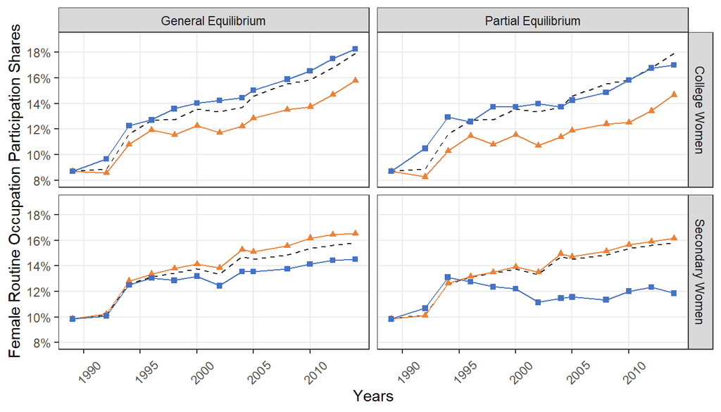

```r
# Routine
pl_flfp_sklocc_routine <- ff_grhlfp_gepeedu_byocc(
  bl_save_img = TRUE,
  st_occ = "Routine",
  y_breaks = round(seq(0.08, 0.18, by = 0.02), 2),
  y_min = 0.08, y_max = 0.19,
  ar_leg_position = "none",
  it_width = it_width, it_height = it_height,
  st_subtitle = st_subtitle
)
print(pl_flfp_sklocc_routine)
```

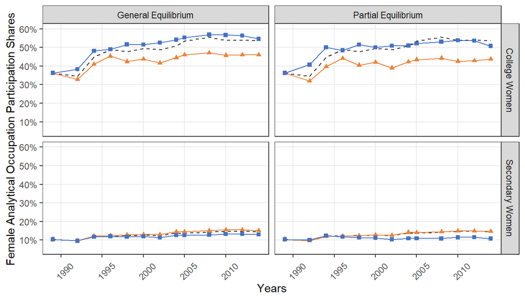

```r
# Analytical
pl_flfp_sklocc_analytical <- ff_grhlfp_gepeedu_byocc(
  bl_save_img = TRUE,
  st_occ = "Analytical",
  y_breaks = round(seq(0.10, 0.60, by = 0.10), 2),
  y_min = 0.05, y_max = 0.60,
  ar_leg_position = "none",
  it_width = it_width, it_height = it_height,
  st_subtitle = st_subtitle
)
print(pl_flfp_sklocc_analytical)
```